# RecPD-Tutorial

```r
#Load the RecPD package:
#Note this command is used to load the RecPD package during development:

#library(devtools)
setwd('/media/cedatorma/Seagate Expansion Drive/psy_project/t3se_clusters/recpd/recpd_pkg/recpd/')
devtools::load_all()

#Alternatively, install the package using library():
#library(recpd)


#Load other packages required for running the examples below:
library(ape)
library(picante)
library(dplyr)
library(tidyr)
library(ggpubr)
library(tibble)
```

# Overview of RecPD

RecPD requires two components (user provided), a species tree, and a presence/absence matrix of traits mapped to the tips of the tree.

To illustrate the different functionalities of RecPD and how to process the metrics it generates, we’ll be using randomly generated phylogenetic trees and presence/absence tip state matrices.

## Randomized Trait Distribution Generation - Version 1

The first approach is to begin with a randomly generated species tree of 10 tips.

```r
r_tr <- rtree(10)
```

The following code chunk provides a function which will generate a matrix of all possible presence/absence feature states on a given tree. Note that this works for a tree of 10 tips, however, this will be computationally unfeasable for trees of larger size (the number of possible presence/absence states combinatorially explodes).

```r
#A function which generates a matrix of permuted features distributions with given
#prevalence across N tips:
feat_rand <- function(tree, prevalence){
  #Prevalence indicates the total number of tips with a state present

  #Steps:
  #1) Set the tip states as an array of length equal to the number of
  #tips in the tree, initialized to 0.

  #2) Generate a set of starting arrays with a single presence states assigned
  #to successive indicies, stopping after reaching an index position P steps
  #away from the end of the array.

  #3) From these starting arrays, repeat the procedure above and iteratatively
  #add an additional presence state until reaching maximum prevalence.

  #A helper function to generate the next permutation from a provided vector of
  #presence/absence states:
  array_return <- function(a){
    a_tmp <- NULL
    a_return <- NULL
    i <- which(a == 1)

    for(j in i[length(i)]:length(a)){
      a_tmp <- a
      a_tmp[j] <- 1
      a_return <- rbind(a_return, a_tmp, deparse.level=0)
    }
    return(a_return)
  }

  l_tmp <- NULL
  a_tmp <- rep(0, Ntip(tree))
  names(a_tmp) <- tree$tip.label

  for(i in 1:(Ntip(tree) - prevalence + 1)){
    a <- a_tmp
    a[i] <- 1
    l_tmp <- rbind(l_tmp, a, deparse.level=0)
  }

  n <- 2
  while(n <= prevalence){
    for(i in 1:nrow(l_tmp)){
      l_tmp <- rbind(l_tmp, array_return(l_tmp[i,]), deparse.level=0)
    }

    l_tmp <- l_tmp[-which(rowSums(l_tmp) < n),]
    n <- n + 1
  }

  if(is.null(nrow(l_tmp))){
    l_tmp <- as.matrix(t(l_tmp))
  }

  return(l_tmp)
}
```

Next, assign randomized presence/absence trait states to the tips of the species tree.

```r
#Generate a list of randomized tip state/locus presence/absence patterns for a given tree:
#Do not include prevalence == Ntip(tree)?

pa_l <- data.frame()

for(i in 1:(Ntip(r_tr)-1)){
  pa_l <- rbind.data.frame(pa_l, data.frame(feat_rand(r_tr, i)))
}


#For testing purposes in other workflows, you can save the random tree &
#associated randomized trait distribution matrix.

#write.tree(r_tr, './random_tree_10tips.tree')
#write.table  (pa_l, col.names = TRUE, row.names=FALSE, sep='\t')
```

To illustrate the output of RecPD, we’ll calculate RecPD for the randomized trait distributions.

```r
res <- recpd_calc(r_tr,   #The species tree
             pa_l,    #The trait presence/absence state matrix, rows = trait stat, columns = corresponding tips of the species tree.
             option='nn', #Ancestral state reconstruction approach to use ('nn' - default, 'mpr', or 'ace')
             calc=TRUE    #Calculate RecPD derived metrics? (default = FALSE)
             )

head(res)
```

```
#>   feature prevalence  recpd nrecpd span cluster longevity lability
#> 1       1          1 0.0745      1    0       0    0.1600    0.000
#> 2       2          1 0.0890      1    0       0    0.1540    0.500
#> 3       3          1 0.0655      1    0       0    0.1070    0.333
#> 4       4          1 0.0947      1    0       0    0.1880    0.250
#> 5       5          1 0.0993      1    0       0    0.0885    0.222
#> 6       6          1 0.1580      1    0       0    0.2390    0.250
```

For each trait, RecPD will produce a data.frame of calculated measures. Primarily what is shown in the console will be the associated metrics calculated for a given feature distribution, and RecPD-derived metrics (if calc == TRUE).

Some useful hidden attributes are also associated with this data.frame, particularly:

- “anc_new” : the final trait evolutionary history reconstructions, with states assigned to tips, internal nodes, and branches of the species phylogenetic tree. These will be used for phylogenetic tree visualizations.
- “anc_old” : preliminary ancestral state reconstructions.
- “tree” : the input phylogenetic tree.

```r
names(attributes(res))
```

```
#> [1] "names"     "row.names" "class"     "anc_old"   "anc_new"   "tree"
```

Now, visualize the RecPD vs. Faith’s PD metrics calculated for each randomized trait distribution:

```r
#Let's also calculate RecPD using other ancestral reconstruction approaches, MPR, and ACE:
res_mpr <- recpd_calc(r_tr,
             pa_l,
             option='mpr',
             calc=FALSE
             )


res_ace <- recpd_calc(r_tr,
             pa_l,
             option='ace',
             calc=FALSE
             )

#Calculate Faith's PD (PD with only vertical descent and loss):

faith <- pd(pa_l, r_tr, include.root=FALSE)$PD/sum(r_tr$edge.length)

#Note that Faith's PD will produce errors for any features with prevalence == 1.


#Merge the results together:

res_merge <- res %>%
  select(feature, prevalence, recpd, nrecpd) %>%
  rename('recpd_nn' = 'recpd', 'nrecpd_nn' = 'nrecpd') %>%
  mutate(recpd_mpr = res_mpr$recpd,
         nrecpd_mpr = res_mpr$nrecpd,
         recpd_ace = res_ace$recpd,
         nrecpd_ace = res_ace$nrecpd) %>%
  mutate(faith = signif(faith, 3), .after = prevalence)
```

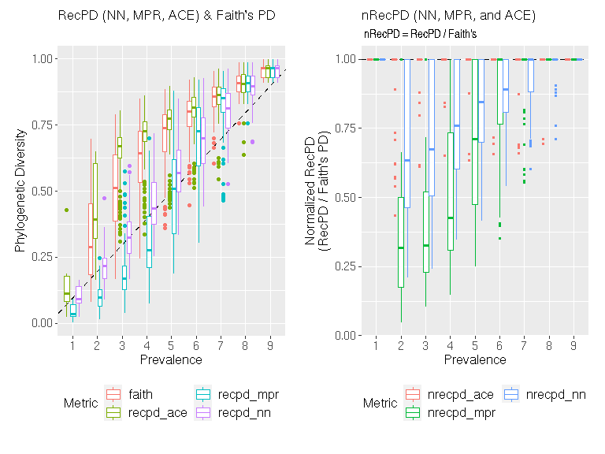

```r
#Plot the results:

#1) RecPD (NN, MPR, ACE) and Faith's PD vs. feature prevalence:
plt1 <- ggplot(res_merge %>%
                 pivot_longer(c(3,4,6,8)),
       aes(factor(prevalence), value, color = name)) +
  geom_abline(intercept = 0, slope = 0.1, lty = 2, lwd = 0.5) +
  geom_boxplot(outlier.size = 1) +
  labs(title = 'RecPD (NN, MPR, ACE) & Faith\'s PD',
       subtitle = '',
       #subtitle='Tree Size - 10 Tips, 1022 Randomized Gene-Family Distributions',
       x = 'Prevalence',
       y = 'Phylogenetic Diversity',
       color = 'Metric') +
  guides(color = guide_legend(nrow=2)) +
  theme(plot.title = element_text(size=12),
        axis.text.x = element_text(size=10),
        axis.text.y = element_text(size=10),
        axis.title.x = element_text(size=12),
        axis.title.y = element_text(size=12),
        legend.title = element_text(size=12),
        legend.text = element_text(size=12),
        plot.margin = unit(c(5,10,20,10), 'points'),
        legend.position = 'bottom')


#2) nRecPD (NN, MPR, ACE) - RecPD normalized to Faith's PD -  vs. Prevalence:
plt2 <- ggplot(res_merge %>% pivot_longer(c(5,7,9)),
       aes(factor(prevalence), value, color=name)) +
  geom_hline(yintercept=1, lty=2, lwd=0.5) +
  geom_boxplot(outlier.size=0.5) +
  labs(title = 'nRecPD (NN, MPR, and ACE)',
       subtitle = ' nRecPD = RecPD / Faith\'s',
       #subtitle='Tree Size - 10 Tips, 1022 Randomized Gene-Family Distributions',
       x = 'Prevalence',
       y = 'Normalized RecPD\n(RecPD / Faith\'s PD)',
       color = 'Metric') +
  guides(color = guide_legend(nrow=2)) +
  theme(plot.title = element_text(size=12),
        axis.text.x = element_text(size=10),
        axis.text.y = element_text(size=10),
        axis.title.x = element_text(size=12),
        axis.title.y = element_text(size=12),
        legend.title = element_text(size=12),
        legend.text = element_text(size=12),
        plot.margin = unit(c(5,10,20,10), 'points'),
        legend.position = 'bottom')


plt1 + plt2
```

Now lets use the results of the RecPD to visualize the evolutionary histories of a given trait mapped onto the species tree.

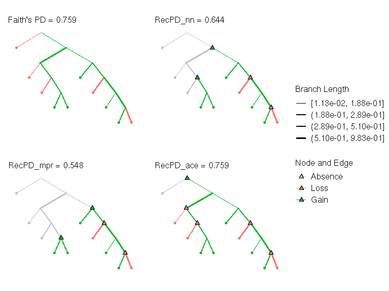

```r
#For example, trait distribution 427
i <- 427

#plt_faith() can be used to visualize evolutionary histories based on vertical ancestry, i.e. inferred using Faith's PD:
plt3 <- plt_faith(res, i)  +
  theme(plot.title=element_text(size=12),
        plot.margin=unit(c(25,10,25,10), 'points'),
        legend.title=element_text(size=12),
        legend.text=element_text(size=12))


#plt_recpd() is used for visualizing RecPD feature ancestral lineages of interest:

#RecPD using Nearest-Neighbours:
plt4 <- plt_recpd(res, i) +
  labs(title=paste0('RecPD_nn = ', signif(res$recpd[i], 3))) +
  theme(plot.title=element_text(size=12),
        plot.margin=unit(c(25,10,25,10), 'points'),
        legend.title=element_text(size=12),
        legend.text=element_text(size=12))

#RecPD using MPR:
plt5 <- plt_recpd(res_mpr, i) +
  labs(title=paste0('RecPD_mpr = ', signif(res_mpr$recpd[i], 3))) +
  theme(plot.title=element_text(size=12),
        plot.margin=unit(c(25,10,25,10), 'points'),
        legend.title=element_text(size=12),
        legend.text=element_text(size=12))

#RecPD using ACE
plt6 <- plt_recpd(res_ace, i) +
  labs(title=paste0('RecPD_ace = ', signif(res_ace$recpd[i], 3))) +
  theme(plot.title=element_text(size=12),
        plot.margin=unit(c(25,10,25,10), 'points'),
        legend.title=element_text(size=12),
        legend.text=element_text(size=12))


plts2 <- ggarrange(plt3, plt4,
                   #ggplot() + theme_void(),
                   plt5, plt6,
                   #ggplot() + theme_void(),
                   common.legend=TRUE, legend='right')


plts2
```

Using recpd_cor_calc() to calculate correlations between the evolutionary histories for pair, or subset, of trait distributions.

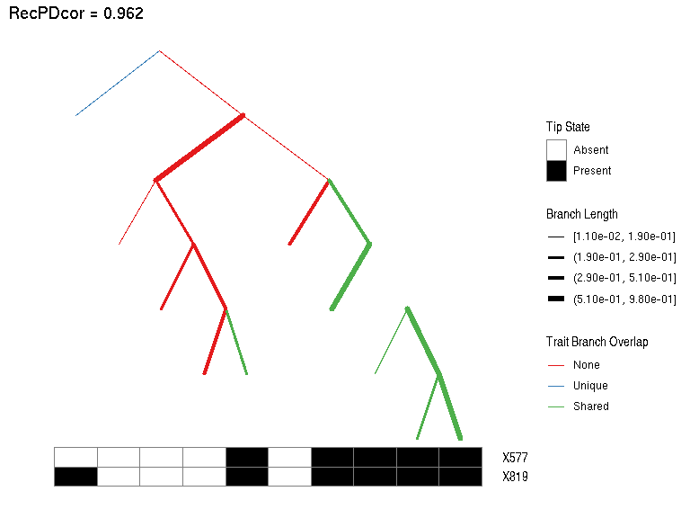

```r
#Calculate recpd_cor:
res_cor <- recpd_cor_calc(res, #The results data.frame from recpd_calc()
               sample(nrow(res), 50) #Randomly sample a subset of features, can be indices or characters.
               )

#Output will be a feature x feature matrix. Pivot it to a long-format pairwise
#table, only retaining unique feature pairs, and removing self feature
#correlations:
res_cor[upper.tri(res_cor)] <- NA

res_cor_tab <- res_cor %>%
  rownames_to_column('feat1') %>%
  pivot_longer(2:ncol(.),
               names_to = 'feat2',
               values_to = 'recpd_cor',
               values_drop_na = TRUE) %>%
  filter(feat1 != feat2)

#Find features with high (>= 99.5th percentile) and low correlated (<= 0.5th percentile) ancestral lineages:
res_cor_filt <- res_cor_tab %>%
  arrange(desc(recpd_cor)) %>%
  mutate(perc = percent_rank(recpd_cor)) %>%
  filter(perc >= 0.995 | perc <= 0.005)

#Plotting the RecPD evolutionary histories for a pair of traits on a species phylogeny:

#1) Highly correlated:
res_cor_max <- res_cor_filt %>%
  slice_max(perc)

plt_recpdcor(res,
             feats = as.character(res_cor_max[1, 1:2]),
             sep.col = 'grey50',
             lab = c(res_cor_max$feat1[1], res_cor_max$feat2[1]),
             colnames.angle = 0) +
  labs(title = paste('RecPDcor =', signif(res_cor[res_cor_max$feat1[1], res_cor_max$feat2[1]], 3)))
```

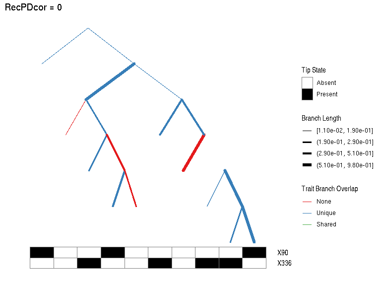

```r
#1) Highly un-correlated:

res_cor_min <- res_cor_filt %>%
  slice_min(perc) %>%
  filter(feat1 > Ntip(r_tr) & feat2 > Ntip(r_tr))

plt_recpdcor(res,
             feats = as.character(res_cor_min[1, 1:2]),
             sep.col = 'grey50',
             lab = c(res_cor_min$feat1[1], res_cor_min$feat2[1]),
             colnames.angle = 0) +
  labs(title = paste('RecPDcor =', signif(res_cor[res_cor_min$feat1[1], res_cor_min$feat2[1]], 3)))
```

## Randomized Trait Distribution Generation - Version 2

To comprehensively investigate how different ancestral state reconstruction approaches affect RecPD, for larger sized trees, we need to devise a different approach for randomly sampling a number of presence/absence tip assignments, at different levels of prevalence.

```r
#A new version of locus_rand2 which allows trees of different sizes to be examined through sampling a certain number of locus distributions:
#using sample() to select which tips will be present:

feat_rand2 <- function(r_tr, prevalence=1, nsamp=10){
  tip <- r_tr$tip.label

  dist <- data.frame()

  i <- 1
  check <- NULL
  while(i <= nsamp){
    d <- ifelse(tip %in% sample(tip, prevalence), 1, 0)

    #check if the trait distribution has previously been generated:
    if(i != 1) check <- which(apply(dist, 1, function(x) identical(as.numeric(x), d)) == TRUE)

    if(length(check) == 0){
      dist <- rbind.data.frame(dist, d)

      i <- i + 1
      check <- NULL
    }

    #Will produce inf if the size of tree tips are <= 200
    if(length(tip) < 200 & i > factorial(length(tip))/(factorial(length(tip)-prevalence)*factorial(prevalence))) break

    if(length(tip) >= 200 & prevalence  == length(tip)) break

  }

  colnames(dist) <- tip
  return(dist)
}



#A function to generate corresponding randomized trait distributions for each tree:
dist_gen <- function(tree_l, nsamp=10){
  #tree_l - a list of randomly generated trees
  #nsamp - the number of randomly generated locus distributions to sample

  #A list to store the randomized distributions generated for each tree topology:
  dist_l <- list()

  for(i in 1:length(tree_l)){
    dist_l[[i]] <- list()

   #To make prevalence comparable between trees of different sizes,
    #Select the prevalence cutoffs using percentile ranges:
    prev <- trunc(quantile(1:Ntip(tree_l[[i]]), probs=seq(0.1, 1, 0.1)))


    for(j in prev){
      dist_l[[i]] <- rbind.data.frame(dist_l[[i]],
                                feat_rand2(tree_l[[i]], prevalence=j, nsamp=nsamp))

    }
  }

  return(dist_l)
}
```

Generate sets of randomized trait distributions for each tree:

```r
#Generate a list of trees of different size:
tree_l <- lapply(c(100, 500, 1000), rtree)

#Generate random trait distributions for each tree:
dist_l <- dist_gen(tree_l, nsamp=10)

#For each tree, calculate RecPD (nn, mpr ace) and faith's PD of each set of randomized trait distributions.
test_res2 <- data.frame()
j <- 1

for(i in 1:length(dist_l)){
  #Note when just the tree toplogy doesn't change, but the branchlength distributions do,
  #do not change the tip state distributions!
  r_nn <- recpd_calc(tree_l[[i]], dist_l[[j]], option='nn')
  r_mpr <- recpd_calc(tree_l[[i]], dist_l[[j]], option='mpr')
  r_ace <- recpd_calc(tree_l[[i]], dist_l[[j]], option='ace')

  faith <- pd(dist_l[[j]], tree_l[[i]], include.root=FALSE)

  ntip <- Ntip(tree_l[[i]])


  test_res2 <- rbind.data.frame(test_res2,
                               data.frame(ntip = ntip,
                                          ntree = j,
                                          prevalence = faith[,2],
                                          faith = faith[,1]/sum(tree_l[[i]]$edge.length),
                                          #faith=faith[,1]/sum(tree_l[[i]][[j]]$edge.length),
                                          recpd_nn = r_nn$recpd,
                                          nrecpd_nn = r_nn$nrecpd,
                                          recpd_mpr = r_mpr$recpd,
                                          nrecpd_mpr = r_mpr$nrecpd,
                                          recpd_ace = r_ace$recpd,
                                          nrecpd_ace = r_ace$nrecpd)
                               )
  j <- j + 1

}

test_res2 <- test_res2 %>%
  mutate(ntip=as.numeric(as.character(ntip)))
```

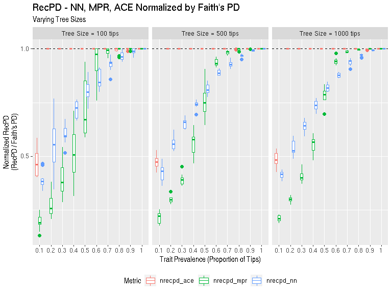

```r
#RecPD normalized to Faith's using different tree sizes:
ggplot(test_res2 %>% pivot_longer(c(6,8,10)),
       aes(factor(prevalence/ntip), value, color=name)) +
  geom_hline(yintercept=1, lwd=0.3, lty=2) +
  geom_boxplot() +
  facet_wrap(~ntip, nrow=1, labeller=labeller(ntip=function(x) paste('Tree Size =', x, 'tips')), scales='free_x') +
  scale_y_continuous(breaks=c(0.5, 1, 1.5)) +
  labs(title='RecPD - NN, MPR, ACE Normalized by Faith\'s PD',
       subtitle='Varying Tree Sizes',
       x='Trait Prevalence (Proportion of Tips)',
       y='Normalized RecPD\n(RecPD / Faith\'s PD)',
       color='Metric') +
  theme(legend.position='bottom')
```